# 1533: Data Mining and Decision Support Systems

## Session 2 Homework

Authors: Alexander Neulinger - 1025792, Michael Graf - 1152091, Filip Minic - 1053044

Let's install all the neccessary packages as a precaution and import them subsequently.

```python
!pip install pandas numpy statsmodels sklearn
```

```python
import random
import matplotlib.pyplot as plt
import numpy as np
import pandas as pd
import statsmodels.api as sm
from sklearn.cross_validation import KFold
from sklearn.linear_model import LinearRegression
% matplotlib inline
```

We read in the online data directly from the link and show the head just to see how it looks like and to make sure that the read was successful.

```python
df = pd.read_csv('http://www-bcf.usc.edu/~gareth/ISL/Advertising.csv', index_col=0)
df.head()
```

|  | TV | radio | newspaper | sales |
| --- | --- | --- | --- | --- |
| 1 | 230.1 | 37.8 | 69.2 | 22.1 |
| 2 | 44.5 | 39.3 | 45.1 | 10.4 |
| 3 | 17.2 | 45.9 | 69.3 | 9.3 |
| 4 | 151.5 | 41.3 | 58.5 | 18.5 |
| 5 | 180.8 | 10.8 | 58.4 | 12.9 |

Here we a do a little house cleaning to make it easier to understand what we are working with semantically. We also add the constant column to make a better fit.

```python
y = df['sales']
X = df[['TV', 'radio']].copy()
X['Constant'] = np.ones(len(df))
X = X.values
y = y.values
```

## Exercise 1

Implement AdaGrad and use it to fit the linear advertising sales model. Wrap AdaGrad into a separate function that requires X and y as input arguments (optional: iterations, default = 10n) and returns the parameter vector b. This function should be used from now on two fit models. What do you observe when comparing it to stochastic gradient descent or the analytic solution using scikit-learn?

Next we implement 3 functions one with adagrad, one without and a fitcheck function to see how well we fit the data with these. We then run a small loop to see how the fit changes based on the number of iterations of 100 and 1000.

```python
# Stochastic gradient descent with AdaGrad
def stochastic_adagrad(X, y, iterations=None):
    if iterations is None:
        iterations = 10 * len(X)
    grad_sum = 0
    b = np.zeros(len(X[0]))
    n = len(y)
    for j in range(iterations):
        i = random.randint(0, n - 1)
        grad = (y[i] - b.dot(X[i])) * -X[i]
        grad_sum += ((y[i] - b.dot(X[i])) * X[i]) ** 2
        b = b - (1. / np.sqrt(grad_sum) * grad)
    return b

# Check the fit with MSE and RSS
def fitcheck(y, b):
    n = len(y)
    rss = sum((y[i] - b.dot(X[i])) ** 2 for i in range(len(y)))
    tss = sum((y[i] - y.mean()) ** 2 for i in range(len(y)))
    r_squared = 1. - rss / tss
    mse = rss / n
    print("Mean Squared Error: " + str(mse) + ". " + "Residual sum of squares: " + str(r_squared))
    return mse, r_squared


# Stochastic gradient descent without AdaGrad
def stochastic_regular(X, y, iterations=10):
    b = np.zeros(len(X[0]))
    alpha = [0.00001, 0.0001, 0.05]
    n = len(y)
    for j in range(iterations):
        i = random.randint(0, n - 1)
        grad = (y[i] - b.dot(X[i])) * -X[i]
        b = b - alpha * grad
    return b


iterations = 10
results_ada_mse = []
results_ada_rss = []
results_stochastic_mse = []
results_stochastic_rss = []

for i in range(2):
    iterations *= 10
    print("Testing stochastic gradient without AdaGrad regarding fit using " + str(iterations) + " iterations.")
    fit = fitcheck(y, stochastic_regular(X, y, iterations))
    results_stochastic_mse.append(fit[0])
    results_stochastic_rss.append(fit[1])
    print("Testing stochastic gradient with AdaGrad regarding fit using " + str(iterations) + " iterations.")
    fit = fitcheck(y, stochastic_adagrad(X, y, iterations))
    results_ada_mse.append(fit[0])
    results_ada_rss.append(fit[1])
    print("\n")

print("Average MSE result for stochastic gradient without AdaGrad " + str(np.mean(results_ada_mse)))
print("Average RSS result for stochastic gradient without AdaGrad " + str(np.mean(results_ada_rss)))
print("Average MSE result for stochastic gradient with AdaGrad " + str(np.mean(results_stochastic_mse)))
print("Average RSS result for stochastic gradient with AdaGrad " + str(np.mean(results_stochastic_rss)))
```

```
Testing stochastic gradient without AdaGrad regarding fit using 100 iterations.
Mean Squared Error: 3.57908728622. Residual sum of squares: 0.867860845201
Testing stochastic gradient with AdaGrad regarding fit using 100 iterations.
Mean Squared Error: 359.959261309. Residual sum of squares: -12.2896207183


Testing stochastic gradient without AdaGrad regarding fit using 1000 iterations.
Mean Squared Error: 3.82006114454. Residual sum of squares: 0.858964140701
Testing stochastic gradient with AdaGrad regarding fit using 1000 iterations.
Mean Squared Error: 3.52188294235. Residual sum of squares: 0.869972817625


Average MSE result for stochastic gradient without AdaGrad 181.740572126
Average RSS result for stochastic gradient without AdaGrad -5.70982395032
Average MSE result for stochastic gradient with AdaGrad 3.69957421538
Average RSS result for stochastic gradient with AdaGrad 0.863412492951
```

## Exercise 2

Run your algorithm to make the following prediction $$Sales = b_0 + b_1 TV$$ and plot the prediction against the original data using Matplotlib.

Here we run our algorithm with the stochastic gradient descent version.

```python
X = df[['TV']].copy()
X['Constant'] = np.ones(len(df))
X = X.values
b = stochastic_adagrad(X, y)
```

```python
y_prediction = y.copy()
for i in range(len(df)):
    y_prediction[i] = b[0] + b[1]*X[i][0]
```

We check some metrics to see how our model is doing AIC can be improved as we will see later, least squares fitting was done by the sm.OLS fitter.

```python
reg = sm.OLS(df['sales'], df[['TV', 'radio']]).fit()
reg.summary()
```

OLS Regression Results

| Dep. Variable: | sales | R-squared: | 0.981 |
| --- | --- | --- | --- |
| Model: | OLS | Adj. R-squared: | 0.981 |
| Method: | Least Squares | F-statistic: | 5206. |
| Date: | Tue, 24 Oct 2017 | Prob (F-statistic): | 6.73e-172 |
| Time: | 22:57:01 | Log-Likelihood: | -426.71 |
| No. Observations: | 200 | AIC: | 857.4 |
| Df Residuals: | 198 | BIC: | 864.0 |
| Df Model: | 2 |  |  |
| Covariance Type: | nonrobust |  |  |

|  | coef | std err | t | P>\|t\| | [0.025 | 0.975] |
| --- | --- | --- | --- | --- | --- | --- |
| TV | 0.0548 | 0.001 | 42.962 | 0.000 | 0.052 | 0.057 |
| radio | 0.2356 | 0.008 | 29.909 | 0.000 | 0.220 | 0.251 |

| Omnibus: | 6.047 | Durbin-Watson: | 2.080 |
| --- | --- | --- | --- |
| Prob(Omnibus): | 0.049 | Jarque-Bera (JB): | 8.829 |
| Skew: | -0.112 | Prob(JB): | 0.0121 |
| Kurtosis: | 4.005 | Cond. No. | 9.37 |

Here we restructure the data and show how our prediction fits in with the sales and if it is a plausible model.

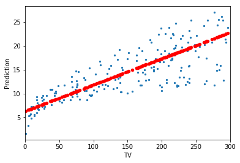

```python
df1 = pd.DataFrame()
df1['sales'] = y_prediction
df1['TV'] = df[['TV']].copy()
XReg = df[['TV']].copy()
XReg['Ones'] = np.ones(len(df))
XReg = XReg.values
df2 = df.copy()
fig, ax = plt.subplots(1, 1)
df['Prediction'] = [b.dot(XReg[i]) for i in range(len(y))]
df2.plot(kind='scatter', x='TV', y='sales', ax=ax, xlim=[0, 300], s=5)
df.plot(kind='scatter', x='TV', y='Prediction', color='red', ax=ax)
plt.show()
```

It seems that it could be a plausible model of a regression.

```python
X = df[['TV', 'radio']].copy()
y = df.sales
reg = LinearRegression()
reg.fit(X, y)
reg.score(X, y)
```

```
0.89719426108289557
```

## Exercise 3

Write an automated variable selection method that iteratively increases the degree of the polynomial for the feature 'TV' by adding this polynomial as an additional column to the feature matrix $X$. Use the AIC to keep track of trade-off between number of model parameters (features) and model fit (RSS) and exit when the minimum AIC is reached.

```python
X = df[['TV', 'radio']].copy()
X['TVxRadio'] = df.TV * df.radio
X = sm.add_constant(X)
reg = sm.OLS(y, X).fit()
print("degree: %d, " % 1, "aic:", reg.aic)
for degree in range(2, 11):
    X['TV^%d' % degree] = X.TV.pow(degree)
    reg = sm.OLS(y, X).fit()
    print("degree: %d, " % degree, "aic:", reg.aic)
```

```
degree: 1,  aic: 548.277841695
degree: 2,  aic: 383.718517832
degree: 3,  aic: 298.309012955
degree: 4,  aic: 247.326443247
degree: 5,  aic: 217.530197655
degree: 6,  aic: 254.705353257
degree: 7,  aic: 761.734121765
degree: 8,  aic: 1210.62389444
degree: 9,  aic: 1253.98282773
degree: 10,  aic: 1290.34609384
```

## Exercise 4

Now use cross validation to select the best order of the polynomial. Automatically stop when the minimum $MSE$ is reached. What do you observe when comparing it to the solution using the AIC?

```python
degree = 1
avg_score = 0.
X = df[['TV', 'radio']].copy()
X['TVxRadio'] = df.TV * df.radio
X = sm.add_constant(X)

for test, train in KFold(n, n_folds=5):
    X_test, X_train = X.values[test], X.values[train]
    y_test, y_train = y.iloc[test], y.iloc[train]
    reg.fit(X_train, y_train)
    avg_score += reg.score(X_test, y_test) / 5.

print("degree: %d, " % degree, "R^2:", avg_score)
avg_score_pre = avg_score

for degree in range(2, 11):
    avg_score = 0.
    X['TV^%d' % degree] = X.TV.pow(degree)

    for test, train in KFold(n, n_folds=5):
        X_test, X_train = X.values[test], X.values[train]
        y_test, y_train = y.iloc[test], y.iloc[train]
        reg.fit(X_train, y_train)
        avg_score += reg.score(X_test, y_test) / 5.

    if avg_score_pre > avg_score:
        break
    else:
        avg_score_pre = avg_score
        print("degree: %d, " % degree, "R^2:", avg_score)

print('Best-Fit: %d ' % (degree - 1), "R^2:", avg_score_pre)
```

```
degree: 1,  R^2: 0.960042161295
degree: 2,  R^2: 0.98208346188
degree: 3,  R^2: 0.987404880642
degree: 4,  R^2: 0.990194182471
degree: 5,  R^2: 0.990920768214
degree: 6,  R^2: 0.991956319411
Best-Fit: 6  R^2: 0.991956319411
```